# Risk Factor Analysis

## Outcome Variable

**Outcome Variable:** stunted

## Predictor Variables

**Intervention Variable:** tr

**Adjustment Set:**

unadjusted

## Stratifying Variables

The analysis was stratified on these variable(s):

- hfoodsec
- agecat
- studyid
- country

## Data Summary

| hfoodsec | agecat | studyid | country | tr | stunted | n_cell | n |
| --- | --- | --- | --- | --- | --- | --- | --- |
| Food Secure | 24 months | ki1000110-WASH-Bangladesh | BANGLADESH | Control | 0 | 117 | 843 |
| Food Secure | 24 months | ki1000110-WASH-Bangladesh | BANGLADESH | Control | 1 | 71 | 843 |
| Food Secure | 24 months | ki1000110-WASH-Bangladesh | BANGLADESH | LNS | 0 | 135 | 843 |
| Food Secure | 24 months | ki1000110-WASH-Bangladesh | BANGLADESH | LNS | 1 | 71 | 843 |
| Food Secure | 24 months | ki1000110-WASH-Bangladesh | BANGLADESH | Other | 0 | 265 | 843 |
| Food Secure | 24 months | ki1000110-WASH-Bangladesh | BANGLADESH | Other | 1 | 184 | 843 |
| Moderately Food Insecure | 24 months | ki1000110-WASH-Bangladesh | BANGLADESH | Control | 0 | 25 | 202 |
| Moderately Food Insecure | 24 months | ki1000110-WASH-Bangladesh | BANGLADESH | Control | 1 | 26 | 202 |
| Moderately Food Insecure | 24 months | ki1000110-WASH-Bangladesh | BANGLADESH | LNS | 0 | 28 | 202 |
| Moderately Food Insecure | 24 months | ki1000110-WASH-Bangladesh | BANGLADESH | LNS | 1 | 28 | 202 |
| Moderately Food Insecure | 24 months | ki1000110-WASH-Bangladesh | BANGLADESH | Other | 0 | 53 | 202 |
| Moderately Food Insecure | 24 months | ki1000110-WASH-Bangladesh | BANGLADESH | Other | 1 | 42 | 202 |
| Mildly Food Insecure | 24 months | ki1000110-WASH-Bangladesh | BANGLADESH | Control | 0 | 12 | 110 |
| Mildly Food Insecure | 24 months | ki1000110-WASH-Bangladesh | BANGLADESH | Control | 1 | 14 | 110 |
| Mildly Food Insecure | 24 months | ki1000110-WASH-Bangladesh | BANGLADESH | LNS | 0 | 20 | 110 |
| Mildly Food Insecure | 24 months | ki1000110-WASH-Bangladesh | BANGLADESH | LNS | 1 | 11 | 110 |
| Mildly Food Insecure | 24 months | ki1000110-WASH-Bangladesh | BANGLADESH | Other | 0 | 33 | 110 |
| Mildly Food Insecure | 24 months | ki1000110-WASH-Bangladesh | BANGLADESH | Other | 1 | 20 | 110 |
| Food Secure | 6 months | ki1000110-WASH-Bangladesh | BANGLADESH | Control | 0 | 94 | 495 |
| Food Secure | 6 months | ki1000110-WASH-Bangladesh | BANGLADESH | Control | 1 | 25 | 495 |
| Food Secure | 6 months | ki1000110-WASH-Bangladesh | BANGLADESH | LNS | 0 | 121 | 495 |
| Food Secure | 6 months | ki1000110-WASH-Bangladesh | BANGLADESH | LNS | 1 | 15 | 495 |
| Food Secure | 6 months | ki1000110-WASH-Bangladesh | BANGLADESH | Other | 0 | 212 | 495 |
| Food Secure | 6 months | ki1000110-WASH-Bangladesh | BANGLADESH | Other | 1 | 28 | 495 |
| Mildly Food Insecure | 6 months | ki1000110-WASH-Bangladesh | BANGLADESH | Control | 0 | 12 | 46 |
| Mildly Food Insecure | 6 months | ki1000110-WASH-Bangladesh | BANGLADESH | Control | 1 | 0 | 46 |
| Mildly Food Insecure | 6 months | ki1000110-WASH-Bangladesh | BANGLADESH | LNS | 0 | 11 | 46 |
| Mildly Food Insecure | 6 months | ki1000110-WASH-Bangladesh | BANGLADESH | LNS | 1 | 1 | 46 |
| Mildly Food Insecure | 6 months | ki1000110-WASH-Bangladesh | BANGLADESH | Other | 0 | 22 | 46 |
| Mildly Food Insecure | 6 months | ki1000110-WASH-Bangladesh | BANGLADESH | Other | 1 | 0 | 46 |

[output cut: 206 more lines]

The following strata were considered:

- hfoodsec: Food Secure, agecat: 24 months, studyid: iLiNS_DYADM_LNS, country: MALAWI
- hfoodsec: Food Secure, agecat: 24 months, studyid: ki1000110-WASH-Bangladesh, country: BANGLADESH
- hfoodsec: Food Secure, agecat: 24 months, studyid: ki1148112-iLiNS-DOSE, country: MALAWI
- hfoodsec: Food Secure, agecat: 24 months, studyid: ki1148112-iLiNS-DYAD-M, country: MALAWI
- hfoodsec: Food Secure, agecat: 24 months, studyid: kiGH5241-JiVitA-3, country: BANGLADESH
- hfoodsec: Food Secure, agecat: 24 months, studyid: kiGH5241-JiVitA-4, country: BANGLADESH
- hfoodsec: Food Secure, agecat: 6 months, studyid: iLiNS_DYADM_LNS, country: MALAWI
- hfoodsec: Food Secure, agecat: 6 months, studyid: ki1000110-WASH-Bangladesh, country: BANGLADESH
- hfoodsec: Food Secure, agecat: 6 months, studyid: ki1148112-iLiNS-DOSE, country: MALAWI
- hfoodsec: Food Secure, agecat: 6 months, studyid: ki1148112-iLiNS-DYAD-M, country: MALAWI
- hfoodsec: Food Secure, agecat: 6 months, studyid: kiGH5241-JiVitA-3, country: BANGLADESH
- hfoodsec: Food Secure, agecat: 6 months, studyid: kiGH5241-JiVitA-4, country: BANGLADESH
- hfoodsec: Food Secure, agecat: Birth, studyid: kiGH5241-JiVitA-3, country: BANGLADESH
- hfoodsec: Food Secure, agecat: Birth, studyid: kiGH5241-JiVitA-4, country: BANGLADESH
- hfoodsec: Mildly Food Insecure, agecat: 24 months, studyid: iLiNS_DYADM_LNS, country: MALAWI
- hfoodsec: Mildly Food Insecure, agecat: 24 months, studyid: ki1000110-WASH-Bangladesh, country: BANGLADESH
- hfoodsec: Mildly Food Insecure, agecat: 24 months, studyid: ki1148112-iLiNS-DOSE, country: MALAWI
- hfoodsec: Mildly Food Insecure, agecat: 24 months, studyid: ki1148112-iLiNS-DYAD-M, country: MALAWI
- hfoodsec: Mildly Food Insecure, agecat: 24 months, studyid: kiGH5241-JiVitA-3, country: BANGLADESH
- hfoodsec: Mildly Food Insecure, agecat: 24 months, studyid: kiGH5241-JiVitA-4, country: BANGLADESH
- hfoodsec: Mildly Food Insecure, agecat: 6 months, studyid: iLiNS_DYADM_LNS, country: MALAWI
- hfoodsec: Mildly Food Insecure, agecat: 6 months, studyid: ki1000110-WASH-Bangladesh, country: BANGLADESH
- hfoodsec: Mildly Food Insecure, agecat: 6 months, studyid: ki1148112-iLiNS-DOSE, country: MALAWI
- hfoodsec: Mildly Food Insecure, agecat: 6 months, studyid: ki1148112-iLiNS-DYAD-M, country: MALAWI
- hfoodsec: Mildly Food Insecure, agecat: 6 months, studyid: kiGH5241-JiVitA-3, country: BANGLADESH
- hfoodsec: Mildly Food Insecure, agecat: 6 months, studyid: kiGH5241-JiVitA-4, country: BANGLADESH
- hfoodsec: Mildly Food Insecure, agecat: Birth, studyid: kiGH5241-JiVitA-3, country: BANGLADESH
- hfoodsec: Mildly Food Insecure, agecat: Birth, studyid: kiGH5241-JiVitA-4, country: BANGLADESH
- hfoodsec: Moderately Food Insecure, agecat: 24 months, studyid: iLiNS_DYADM_LNS, country: MALAWI
- hfoodsec: Moderately Food Insecure, agecat: 24 months, studyid: ki1000110-WASH-Bangladesh, country: BANGLADESH
- hfoodsec: Moderately Food Insecure, agecat: 24 months, studyid: ki1148112-iLiNS-DOSE, country: MALAWI
- hfoodsec: Moderately Food Insecure, agecat: 24 months, studyid: ki1148112-iLiNS-DYAD-M, country: MALAWI
- hfoodsec: Moderately Food Insecure, agecat: 24 months, studyid: kiGH5241-JiVitA-3, country: BANGLADESH
- hfoodsec: Moderately Food Insecure, agecat: 24 months, studyid: kiGH5241-JiVitA-4, country: BANGLADESH
- hfoodsec: Moderately Food Insecure, agecat: 6 months, studyid: iLiNS_DYADM_LNS, country: MALAWI
- hfoodsec: Moderately Food Insecure, agecat: 6 months, studyid: ki1000110-WASH-Bangladesh, country: BANGLADESH
- hfoodsec: Moderately Food Insecure, agecat: 6 months, studyid: ki1148112-iLiNS-DOSE, country: MALAWI
- hfoodsec: Moderately Food Insecure, agecat: 6 months, studyid: ki1148112-iLiNS-DYAD-M, country: MALAWI
- hfoodsec: Moderately Food Insecure, agecat: 6 months, studyid: kiGH5241-JiVitA-3, country: BANGLADESH
- hfoodsec: Moderately Food Insecure, agecat: 6 months, studyid: kiGH5241-JiVitA-4, country: BANGLADESH
- hfoodsec: Moderately Food Insecure, agecat: Birth, studyid: kiGH5241-JiVitA-3, country: BANGLADESH
- hfoodsec: Moderately Food Insecure, agecat: Birth, studyid: kiGH5241-JiVitA-4, country: BANGLADESH
- hfoodsec: Severely Food Insecure, agecat: 24 months, studyid: iLiNS_DYADM_LNS, country: MALAWI
- hfoodsec: Severely Food Insecure, agecat: 24 months, studyid: ki1000110-WASH-Bangladesh, country: BANGLADESH
- hfoodsec: Severely Food Insecure, agecat: 24 months, studyid: ki1148112-iLiNS-DOSE, country: MALAWI
- hfoodsec: Severely Food Insecure, agecat: 24 months, studyid: ki1148112-iLiNS-DYAD-M, country: MALAWI
- hfoodsec: Severely Food Insecure, agecat: 6 months, studyid: iLiNS_DYADM_LNS, country: MALAWI
- hfoodsec: Severely Food Insecure, agecat: 6 months, studyid: ki1000110-WASH-Bangladesh, country: BANGLADESH
- hfoodsec: Severely Food Insecure, agecat: 6 months, studyid: ki1148112-iLiNS-DOSE, country: MALAWI
- hfoodsec: Severely Food Insecure, agecat: 6 months, studyid: ki1148112-iLiNS-DYAD-M, country: MALAWI
- hfoodsec: Severely Food Insecure, agecat: Birth, studyid: iLiNS_DYADM_LNS, country: MALAWI
- hfoodsec: Severely Food Insecure, agecat: Birth, studyid: ki1148112-iLiNS-DYAD-M, country: MALAWI

### Dropped Strata

Some strata were dropped due to rare outcomes:

- hfoodsec: Mildly Food Insecure, agecat: 6 months, studyid: ki1000110-WASH-Bangladesh, country: BANGLADESH
- hfoodsec: Severely Food Insecure, agecat: 24 months, studyid: ki1000110-WASH-Bangladesh, country: BANGLADESH
- hfoodsec: Moderately Food Insecure, agecat: 6 months, studyid: ki1000110-WASH-Bangladesh, country: BANGLADESH
- hfoodsec: Severely Food Insecure, agecat: 6 months, studyid: ki1000110-WASH-Bangladesh, country: BANGLADESH
- hfoodsec: Mildly Food Insecure, agecat: 24 months, studyid: ki1148112-iLiNS-DOSE, country: MALAWI
- hfoodsec: Severely Food Insecure, agecat: Birth, studyid: ki1148112-iLiNS-DYAD-M, country: MALAWI
- hfoodsec: Moderately Food Insecure, agecat: 24 months, studyid: ki1148112-iLiNS-DYAD-M, country: MALAWI
- hfoodsec: Mildly Food Insecure, agecat: 24 months, studyid: ki1148112-iLiNS-DYAD-M, country: MALAWI
- hfoodsec: Food Secure, agecat: 24 months, studyid: ki1148112-iLiNS-DYAD-M, country: MALAWI
- hfoodsec: Severely Food Insecure, agecat: 24 months, studyid: ki1148112-iLiNS-DYAD-M, country: MALAWI
- hfoodsec: Mildly Food Insecure, agecat: 24 months, studyid: kiGH5241-JiVitA-3, country: BANGLADESH
- hfoodsec: Moderately Food Insecure, agecat: 24 months, studyid: kiGH5241-JiVitA-3, country: BANGLADESH
- hfoodsec: Severely Food Insecure, agecat: Birth, studyid: iLiNS_DYADM_LNS, country: MALAWI
- hfoodsec: Moderately Food Insecure, agecat: 24 months, studyid: iLiNS_DYADM_LNS, country: MALAWI
- hfoodsec: Mildly Food Insecure, agecat: 24 months, studyid: iLiNS_DYADM_LNS, country: MALAWI
- hfoodsec: Food Secure, agecat: 24 months, studyid: iLiNS_DYADM_LNS, country: MALAWI
- hfoodsec: Severely Food Insecure, agecat: 24 months, studyid: iLiNS_DYADM_LNS, country: MALAWI

## Methods Detail

We’re interested in the causal parameters $E[Y_a]$ for all values of $a \in \mathcal{A}$. These parameters represent the mean outcome if, possibly contrary to fact, we intervened to set all units to have $A=a$. Under the randomization and positivity assumptions, these are identified by the statistical parameters $\psi_a=E_W[E_{Y|A,W}(Y|A=a,W)]$. In addition, we’re interested in the mean of $Y$, $E[Y]$ under no intervention (the observed mean). We will estimate these parameters by using SuperLearner to fit the relevant likelihood factors – $E_{Y|A,W}(Y|A=a,W)$ and $p(A=a|W)$, and then updating our likelihood fit using a joint TMLE.

For unadjusted analyses ($W=\{\}$), initial likelihoods were estimated using Lrnr_glm to estimate the simple $E(Y|A)$ and Lrnr_mean to estimate $p(A)$. For adjusted analyses, a small library containing Lrnr_glmnet, Lrnr_xgboost, and Lrnr_mean was used.

Having estimated these parameters, we will then use the delta method to estimate relative risks and attributable risks relative to a prespecified baseline level of $A$.

# Results Detail

## Results Plots

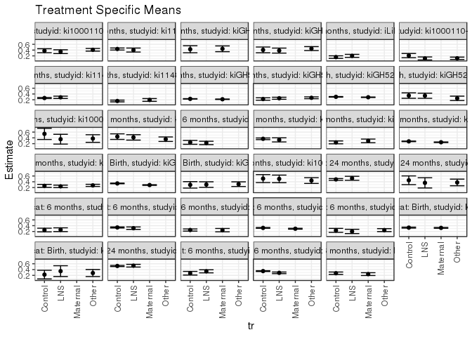

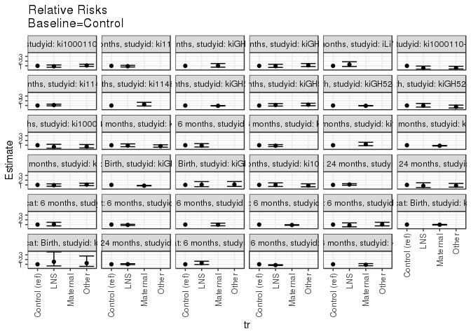

[figure not shown]

[figure not shown]

## Results Table

### Parameter: TSM

| hfoodsec | agecat | studyid | country | intervention_level | baseline_level | estimate | ci_lower | ci_upper |
| --- | --- | --- | --- | --- | --- | --- | --- | --- |
| Food Secure | Birth | kiGH5241-JiVitA-3 | BANGLADESH | Control | NA | 0.3013745 | 0.2911843 | 0.3115646 |
| Food Secure | Birth | kiGH5241-JiVitA-3 | BANGLADESH | Maternal | NA | 0.2869940 | 0.2784365 | 0.2955516 |
| Food Secure | Birth | kiGH5241-JiVitA-4 | BANGLADESH | Control | NA | 0.3448276 | 0.2508535 | 0.4388017 |
| Food Secure | Birth | kiGH5241-JiVitA-4 | BANGLADESH | LNS | NA | 0.3392857 | 0.2500926 | 0.4284788 |
| Food Secure | Birth | kiGH5241-JiVitA-4 | BANGLADESH | Other | NA | 0.2500000 | 0.1747163 | 0.3252837 |
| Food Secure | 6 months | iLiNS_DYADM_LNS | MALAWI | Control | NA | 0.1578947 | 0.1134848 | 0.2023047 |
| Food Secure | 6 months | iLiNS_DYADM_LNS | MALAWI | LNS | NA | 0.2000000 | 0.1479774 | 0.2520226 |
| Food Secure | 6 months | ki1000110-WASH-Bangladesh | BANGLADESH | Control | NA | 0.2100840 | 0.1368183 | 0.2833497 |
| Food Secure | 6 months | ki1000110-WASH-Bangladesh | BANGLADESH | LNS | NA | 0.1102941 | 0.0575933 | 0.1629949 |
| Food Secure | 6 months | ki1000110-WASH-Bangladesh | BANGLADESH | Other | NA | 0.1166667 | 0.0760114 | 0.1573220 |
| Food Secure | 6 months | ki1148112-iLiNS-DOSE | MALAWI | Control | NA | 0.2602740 | 0.2418813 | 0.2786666 |
| Food Secure | 6 months | ki1148112-iLiNS-DOSE | MALAWI | LNS | NA | 0.2844037 | 0.2443809 | 0.3244264 |
| Food Secure | 6 months | ki1148112-iLiNS-DYAD-M | MALAWI | Control | NA | 0.1578947 | 0.1280012 | 0.1877883 |
| Food Secure | 6 months | ki1148112-iLiNS-DYAD-M | MALAWI | Maternal | NA | 0.1935484 | 0.1457771 | 0.2413197 |
| Food Secure | 6 months | kiGH5241-JiVitA-3 | BANGLADESH | Control | NA | 0.2308795 | 0.2238576 | 0.2379015 |
| Food Secure | 6 months | kiGH5241-JiVitA-3 | BANGLADESH | Maternal | NA | 0.2180095 | 0.2102914 | 0.2257275 |
| Food Secure | 6 months | kiGH5241-JiVitA-4 | BANGLADESH | Control | NA | 0.2259084 | 0.1840449 | 0.2677719 |
| Food Secure | 6 months | kiGH5241-JiVitA-4 | BANGLADESH | LNS | NA | 0.2525547 | 0.2178919 | 0.2872176 |
| Food Secure | 6 months | kiGH5241-JiVitA-4 | BANGLADESH | Other | NA | 0.2683590 | 0.2368672 | 0.2998509 |
| Food Secure | 24 months | ki1000110-WASH-Bangladesh | BANGLADESH | Control | NA | 0.3776596 | 0.3083184 | 0.4470007 |
| Food Secure | 24 months | ki1000110-WASH-Bangladesh | BANGLADESH | LNS | NA | 0.3446602 | 0.2797219 | 0.4095985 |
| Food Secure | 24 months | ki1000110-WASH-Bangladesh | BANGLADESH | Other | NA | 0.4097996 | 0.3642831 | 0.4553160 |
| Food Secure | 24 months | ki1148112-iLiNS-DOSE | MALAWI | Control | NA | 0.4375000 | 0.4027987 | 0.4722013 |
| Food Secure | 24 months | ki1148112-iLiNS-DOSE | MALAWI | LNS | NA | 0.4015748 | 0.3332606 | 0.4698890 |
| Food Secure | 24 months | kiGH5241-JiVitA-3 | BANGLADESH | Control | NA | 0.4285714 | 0.3067852 | 0.5503577 |
| Food Secure | 24 months | kiGH5241-JiVitA-3 | BANGLADESH | Maternal | NA | 0.4444444 | 0.3448707 | 0.5440182 |
| Food Secure | 24 months | kiGH5241-JiVitA-4 | BANGLADESH | Control | NA | 0.4057971 | 0.3060263 | 0.5055679 |
| Food Secure | 24 months | kiGH5241-JiVitA-4 | BANGLADESH | LNS | NA | 0.3825503 | 0.2959349 | 0.4691658 |
| Food Secure | 24 months | kiGH5241-JiVitA-4 | BANGLADESH | Other | NA | 0.4520000 | 0.3845066 | 0.5194934 |
| Mildly Food Insecure | Birth | kiGH5241-JiVitA-3 | BANGLADESH | Control | NA | 0.3424721 | 0.3307293 | 0.3542149 |

[output cut: 53 more lines]

### Parameter: E(Y)

| hfoodsec | agecat | studyid | country | intervention_level | baseline_level | estimate | ci_lower | ci_upper |
| --- | --- | --- | --- | --- | --- | --- | --- | --- |
| Food Secure | Birth | kiGH5241-JiVitA-3 | BANGLADESH | NA | NA | 0.2941471 | 0.2808057 | 0.3074885 |
| Food Secure | Birth | kiGH5241-JiVitA-4 | BANGLADESH | NA | NA | 0.3030303 | 0.2535848 | 0.3524758 |
| Food Secure | 6 months | iLiNS_DYADM_LNS | MALAWI | NA | NA | 0.1803279 | 0.1118253 | 0.2488304 |
| Food Secure | 6 months | ki1000110-WASH-Bangladesh | BANGLADESH | NA | NA | 0.1373737 | 0.1070175 | 0.1677300 |
| Food Secure | 6 months | ki1148112-iLiNS-DOSE | MALAWI | NA | NA | 0.2800000 | 0.2359438 | 0.3240562 |
| Food Secure | 6 months | ki1148112-iLiNS-DYAD-M | MALAWI | NA | NA | 0.1823204 | 0.1259150 | 0.2387259 |
| Food Secure | 6 months | kiGH5241-JiVitA-3 | BANGLADESH | NA | NA | 0.2244169 | 0.2139664 | 0.2348675 |
| Food Secure | 6 months | kiGH5241-JiVitA-4 | BANGLADESH | NA | NA | 0.2527881 | 0.2322256 | 0.2733506 |
| Food Secure | 24 months | ki1000110-WASH-Bangladesh | BANGLADESH | NA | NA | 0.3867141 | 0.3538200 | 0.4196083 |
| Food Secure | 24 months | ki1148112-iLiNS-DOSE | MALAWI | NA | NA | 0.4088050 | 0.3321496 | 0.4854605 |
| Food Secure | 24 months | kiGH5241-JiVitA-3 | BANGLADESH | NA | NA | 0.4358974 | 0.2785836 | 0.5932113 |
| Food Secure | 24 months | kiGH5241-JiVitA-4 | BANGLADESH | NA | NA | 0.4208566 | 0.3735416 | 0.4681716 |
| Mildly Food Insecure | Birth | kiGH5241-JiVitA-3 | BANGLADESH | NA | NA | 0.3144175 | 0.2970608 | 0.3317743 |
| Mildly Food Insecure | Birth | kiGH5241-JiVitA-4 | BANGLADESH | NA | NA | 0.3074434 | 0.2533436 | 0.3615431 |
| Mildly Food Insecure | 6 months | iLiNS_DYADM_LNS | MALAWI | NA | NA | 0.2359551 | 0.1472434 | 0.3246667 |
| Mildly Food Insecure | 6 months | ki1148112-iLiNS-DOSE | MALAWI | NA | NA | 0.3355705 | 0.2594969 | 0.4116440 |
| Mildly Food Insecure | 6 months | ki1148112-iLiNS-DYAD-M | MALAWI | NA | NA | 0.2750000 | 0.1947750 | 0.3552250 |
| Mildly Food Insecure | 6 months | kiGH5241-JiVitA-3 | BANGLADESH | NA | NA | 0.2638740 | 0.2493868 | 0.2783612 |
| Mildly Food Insecure | 6 months | kiGH5241-JiVitA-4 | BANGLADESH | NA | NA | 0.2617801 | 0.2370674 | 0.2864928 |
| Mildly Food Insecure | 24 months | ki1000110-WASH-Bangladesh | BANGLADESH | NA | NA | 0.4090909 | 0.3167902 | 0.5013916 |
| Mildly Food Insecure | 24 months | kiGH5241-JiVitA-4 | BANGLADESH | NA | NA | 0.3960880 | 0.3451854 | 0.4469907 |
| Moderately Food Insecure | Birth | kiGH5241-JiVitA-3 | BANGLADESH | NA | NA | 0.3282006 | 0.3041845 | 0.3522167 |
| Moderately Food Insecure | Birth | kiGH5241-JiVitA-4 | BANGLADESH | NA | NA | 0.2807018 | 0.1956190 | 0.3657845 |
| Moderately Food Insecure | 6 months | iLiNS_DYADM_LNS | MALAWI | NA | NA | 0.2555556 | 0.1649381 | 0.3461730 |
| Moderately Food Insecure | 6 months | ki1148112-iLiNS-DOSE | MALAWI | NA | NA | 0.3179487 | 0.2716722 | 0.3642252 |
| Moderately Food Insecure | 6 months | ki1148112-iLiNS-DYAD-M | MALAWI | NA | NA | 0.2467532 | 0.1784404 | 0.3150661 |
| Moderately Food Insecure | 6 months | kiGH5241-JiVitA-3 | BANGLADESH | NA | NA | 0.3087224 | 0.2870592 | 0.3303856 |
| Moderately Food Insecure | 6 months | kiGH5241-JiVitA-4 | BANGLADESH | NA | NA | 0.2331190 | 0.1972954 | 0.2689426 |
| Moderately Food Insecure | 24 months | ki1000110-WASH-Bangladesh | BANGLADESH | NA | NA | 0.4752475 | 0.4062097 | 0.5442854 |
| Moderately Food Insecure | 24 months | ki1148112-iLiNS-DOSE | MALAWI | NA | NA | 0.5146199 | 0.4394908 | 0.5897489 |
| Moderately Food Insecure | 24 months | kiGH5241-JiVitA-4 | BANGLADESH | NA | NA | 0.3958333 | 0.3143515 | 0.4773151 |
| Severely Food Insecure | 6 months | iLiNS_DYADM_LNS | MALAWI | NA | NA | 0.3000000 | 0.2176650 | 0.3823350 |
| Severely Food Insecure | 6 months | ki1148112-iLiNS-DOSE | MALAWI | NA | NA | 0.2973934 | 0.2665362 | 0.3282505 |
| Severely Food Insecure | 6 months | ki1148112-iLiNS-DYAD-M | MALAWI | NA | NA | 0.2555556 | 0.1916586 | 0.3194525 |
| Severely Food Insecure | 24 months | ki1148112-iLiNS-DOSE | MALAWI | NA | NA | 0.5324324 | 0.4815240 | 0.5833408 |

### Parameter: RR

| hfoodsec | agecat | studyid | country | intervention_level | baseline_level | estimate | ci_lower | ci_upper |
| --- | --- | --- | --- | --- | --- | --- | --- | --- |
| Food Secure | Birth | kiGH5241-JiVitA-3 | BANGLADESH | Control | Control | 1.0000000 | 1.0000000 | 1.0000000 |
| Food Secure | Birth | kiGH5241-JiVitA-3 | BANGLADESH | Maternal | Control | 0.9522839 | 0.9103155 | 0.9961871 |
| Food Secure | Birth | kiGH5241-JiVitA-4 | BANGLADESH | Control | Control | 1.0000000 | 1.0000000 | 1.0000000 |
| Food Secure | Birth | kiGH5241-JiVitA-4 | BANGLADESH | LNS | Control | 0.9839286 | 0.6738808 | 1.4366270 |
| Food Secure | Birth | kiGH5241-JiVitA-4 | BANGLADESH | Other | Control | 0.7250000 | 0.4829616 | 1.0883370 |
| Food Secure | 6 months | iLiNS_DYADM_LNS | MALAWI | Control | Control | 1.0000000 | 1.0000000 | 1.0000000 |
| Food Secure | 6 months | iLiNS_DYADM_LNS | MALAWI | LNS | Control | 1.2666667 | 0.8635411 | 1.8579827 |
| Food Secure | 6 months | ki1000110-WASH-Bangladesh | BANGLADESH | Control | Control | 1.0000000 | 1.0000000 | 1.0000000 |
| Food Secure | 6 months | ki1000110-WASH-Bangladesh | BANGLADESH | LNS | Control | 0.5250000 | 0.2905701 | 0.9485662 |
| Food Secure | 6 months | ki1000110-WASH-Bangladesh | BANGLADESH | Other | Control | 0.5553333 | 0.3391900 | 0.9092106 |
| Food Secure | 6 months | ki1148112-iLiNS-DOSE | MALAWI | Control | Control | 1.0000000 | 1.0000000 | 1.0000000 |
| Food Secure | 6 months | ki1148112-iLiNS-DOSE | MALAWI | LNS | Control | 1.0927088 | 0.9335022 | 1.2790677 |
| Food Secure | 6 months | ki1148112-iLiNS-DYAD-M | MALAWI | Control | Control | 1.0000000 | 1.0000000 | 1.0000000 |
| Food Secure | 6 months | ki1148112-iLiNS-DYAD-M | MALAWI | Maternal | Control | 1.2258065 | 0.8981039 | 1.6730819 |
| Food Secure | 6 months | kiGH5241-JiVitA-3 | BANGLADESH | Control | Control | 1.0000000 | 1.0000000 | 1.0000000 |
| Food Secure | 6 months | kiGH5241-JiVitA-3 | BANGLADESH | Maternal | Control | 0.9442564 | 0.9011981 | 0.9893720 |
| Food Secure | 6 months | kiGH5241-JiVitA-4 | BANGLADESH | Control | Control | 1.0000000 | 1.0000000 | 1.0000000 |
| Food Secure | 6 months | kiGH5241-JiVitA-4 | BANGLADESH | LNS | Control | 1.1179521 | 0.8877568 | 1.4078371 |
| Food Secure | 6 months | kiGH5241-JiVitA-4 | BANGLADESH | Other | Control | 1.1879109 | 0.9539485 | 1.4792542 |
| Food Secure | 24 months | ki1000110-WASH-Bangladesh | BANGLADESH | Control | Control | 1.0000000 | 1.0000000 | 1.0000000 |
| Food Secure | 24 months | ki1000110-WASH-Bangladesh | BANGLADESH | LNS | Control | 0.9126214 | 0.7015142 | 1.1872572 |
| Food Secure | 24 months | ki1000110-WASH-Bangladesh | BANGLADESH | Other | Control | 1.0851030 | 0.8755406 | 1.3448246 |
| Food Secure | 24 months | ki1148112-iLiNS-DOSE | MALAWI | Control | Control | 1.0000000 | 1.0000000 | 1.0000000 |
| Food Secure | 24 months | ki1148112-iLiNS-DOSE | MALAWI | LNS | Control | 0.9178853 | 0.7608028 | 1.1074004 |
| Food Secure | 24 months | kiGH5241-JiVitA-3 | BANGLADESH | Control | Control | 1.0000000 | 1.0000000 | 1.0000000 |
| Food Secure | 24 months | kiGH5241-JiVitA-3 | BANGLADESH | Maternal | Control | 1.0370370 | 0.7221686 | 1.4891894 |
| Food Secure | 24 months | kiGH5241-JiVitA-4 | BANGLADESH | Control | Control | 1.0000000 | 1.0000000 | 1.0000000 |
| Food Secure | 24 months | kiGH5241-JiVitA-4 | BANGLADESH | LNS | Control | 0.9427133 | 0.6749379 | 1.3167262 |
| Food Secure | 24 months | kiGH5241-JiVitA-4 | BANGLADESH | Other | Control | 1.1138571 | 0.8355004 | 1.4849517 |
| Mildly Food Insecure | Birth | kiGH5241-JiVitA-3 | BANGLADESH | Control | Control | 1.0000000 | 1.0000000 | 1.0000000 |

[output cut: 53 more lines]

### Parameter: PAR

| hfoodsec | agecat | studyid | country | intervention_level | baseline_level | estimate | ci_lower | ci_upper |
| --- | --- | --- | --- | --- | --- | --- | --- | --- |
| Food Secure | Birth | kiGH5241-JiVitA-3 | BANGLADESH | Control | NA | -0.0072274 | -0.0158264 | 0.0013717 |
| Food Secure | Birth | kiGH5241-JiVitA-4 | BANGLADESH | Control | NA | -0.0417973 | -0.1196782 | 0.0360836 |
| Food Secure | 6 months | iLiNS_DYADM_LNS | MALAWI | Control | NA | 0.0224331 | -0.0297240 | 0.0745902 |
| Food Secure | 6 months | ki1000110-WASH-Bangladesh | BANGLADESH | Control | NA | -0.0727103 | -0.1336074 | -0.0118132 |
| Food Secure | 6 months | ki1148112-iLiNS-DOSE | MALAWI | Control | NA | 0.0197260 | -0.0203072 | 0.0597592 |
| Food Secure | 6 months | ki1148112-iLiNS-DYAD-M | MALAWI | Control | NA | 0.0244257 | -0.0234068 | 0.0722583 |
| Food Secure | 6 months | kiGH5241-JiVitA-3 | BANGLADESH | Control | NA | -0.0064626 | -0.0142026 | 0.0012774 |
| Food Secure | 6 months | kiGH5241-JiVitA-4 | BANGLADESH | Control | NA | 0.0268797 | -0.0086589 | 0.0624184 |
| Food Secure | 24 months | ki1000110-WASH-Bangladesh | BANGLADESH | Control | NA | 0.0090545 | -0.0521471 | 0.0702562 |
| Food Secure | 24 months | ki1148112-iLiNS-DOSE | MALAWI | Control | NA | -0.0286950 | -0.0970461 | 0.0396561 |
| Food Secure | 24 months | kiGH5241-JiVitA-3 | BANGLADESH | Control | NA | 0.0073260 | -0.0922519 | 0.1069039 |
| Food Secure | 24 months | kiGH5241-JiVitA-4 | BANGLADESH | Control | NA | 0.0150595 | -0.0689474 | 0.0990664 |
| Mildly Food Insecure | Birth | kiGH5241-JiVitA-3 | BANGLADESH | Control | NA | -0.0280546 | -0.0410276 | -0.0150816 |
| Mildly Food Insecure | Birth | kiGH5241-JiVitA-4 | BANGLADESH | Control | NA | 0.0141100 | -0.0821495 | 0.1103695 |
| Mildly Food Insecure | 6 months | iLiNS_DYADM_LNS | MALAWI | Control | NA | -0.0089429 | -0.0674698 | 0.0495839 |
| Mildly Food Insecure | 6 months | ki1148112-iLiNS-DOSE | MALAWI | Control | NA | -0.0328506 | -0.1036816 | 0.0379804 |
| Mildly Food Insecure | 6 months | ki1148112-iLiNS-DYAD-M | MALAWI | Control | NA | 0.0301020 | -0.0331317 | 0.0933357 |
| Mildly Food Insecure | 6 months | kiGH5241-JiVitA-3 | BANGLADESH | Control | NA | -0.0156607 | -0.0259427 | -0.0053787 |
| Mildly Food Insecure | 6 months | kiGH5241-JiVitA-4 | BANGLADESH | Control | NA | 0.0036406 | -0.0402183 | 0.0474994 |
| Mildly Food Insecure | 24 months | ki1000110-WASH-Bangladesh | BANGLADESH | Control | NA | -0.1293706 | -0.2968750 | 0.0381338 |
| Mildly Food Insecure | 24 months | kiGH5241-JiVitA-4 | BANGLADESH | Control | NA | -0.0473082 | -0.1317301 | 0.0371137 |
| Moderately Food Insecure | Birth | kiGH5241-JiVitA-3 | BANGLADESH | Control | NA | -0.0039549 | -0.0203826 | 0.0124728 |
| Moderately Food Insecure | Birth | kiGH5241-JiVitA-4 | BANGLADESH | Control | NA | 0.0548953 | -0.0771513 | 0.1869419 |
| Moderately Food Insecure | 6 months | iLiNS_DYADM_LNS | MALAWI | Control | NA | 0.0055556 | -0.0596745 | 0.0707857 |
| Moderately Food Insecure | 6 months | ki1148112-iLiNS-DOSE | MALAWI | Control | NA | -0.0207610 | -0.0630679 | 0.0215460 |
| Moderately Food Insecure | 6 months | ki1148112-iLiNS-DYAD-M | MALAWI | Control | NA | -0.0032468 | -0.0608801 | 0.0543866 |
| Moderately Food Insecure | 6 months | kiGH5241-JiVitA-3 | BANGLADESH | Control | NA | -0.0145693 | -0.0297395 | 0.0006010 |
| Moderately Food Insecure | 6 months | kiGH5241-JiVitA-4 | BANGLADESH | Control | NA | -0.0038752 | -0.0620076 | 0.0542571 |
| Moderately Food Insecure | 24 months | ki1000110-WASH-Bangladesh | BANGLADESH | Control | NA | -0.0345564 | -0.1534308 | 0.0843180 |
| Moderately Food Insecure | 24 months | ki1148112-iLiNS-DOSE | MALAWI | Control | NA | 0.0331384 | -0.0358081 | 0.1020849 |
| Moderately Food Insecure | 24 months | kiGH5241-JiVitA-4 | BANGLADESH | Control | NA | -0.0565476 | -0.1833409 | 0.0702457 |
| Severely Food Insecure | 6 months | iLiNS_DYADM_LNS | MALAWI | Control | NA | 0.0260274 | -0.0275718 | 0.0796266 |
| Severely Food Insecure | 6 months | ki1148112-iLiNS-DOSE | MALAWI | Control | NA | -0.0498289 | -0.0776846 | -0.0219731 |
| Severely Food Insecure | 6 months | ki1148112-iLiNS-DYAD-M | MALAWI | Control | NA | -0.0184170 | -0.0669103 | 0.0300762 |
| Severely Food Insecure | 24 months | ki1148112-iLiNS-DOSE | MALAWI | Control | NA | 0.0078423 | -0.0386725 | 0.0543570 |

### Parameter: PAF

| hfoodsec | agecat | studyid | country | intervention_level | baseline_level | estimate | ci_lower | ci_upper |
| --- | --- | --- | --- | --- | --- | --- | --- | --- |
| Food Secure | Birth | kiGH5241-JiVitA-3 | BANGLADESH | Control | NA | -0.0245706 | -0.0549783 | 0.0049606 |
| Food Secure | Birth | kiGH5241-JiVitA-4 | BANGLADESH | Control | NA | -0.1379310 | -0.4263353 | 0.0921581 |
| Food Secure | 6 months | iLiNS_DYADM_LNS | MALAWI | Control | NA | 0.1244019 | -0.1717466 | 0.3457015 |
| Food Secure | 6 months | ki1000110-WASH-Bangladesh | BANGLADESH | Control | NA | -0.5292882 | -1.0328736 | -0.1504515 |
| Food Secure | 6 months | ki1148112-iLiNS-DOSE | MALAWI | Control | NA | 0.0704501 | -0.0725164 | 0.1943591 |
| Food Secure | 6 months | ki1148112-iLiNS-DYAD-M | MALAWI | Control | NA | 0.1339713 | -0.1272041 | 0.3346318 |
| Food Secure | 6 months | kiGH5241-JiVitA-3 | BANGLADESH | Control | NA | -0.0287973 | -0.0649106 | 0.0060913 |
| Food Secure | 6 months | kiGH5241-JiVitA-4 | BANGLADESH | Control | NA | 0.1063331 | -0.0466874 | 0.2369827 |
| Food Secure | 24 months | ki1000110-WASH-Bangladesh | BANGLADESH | Control | NA | 0.0234140 | -0.1483952 | 0.1695192 |
| Food Secure | 24 months | ki1148112-iLiNS-DOSE | MALAWI | Control | NA | -0.0701923 | -0.2650712 | 0.0946663 |
| Food Secure | 24 months | kiGH5241-JiVitA-3 | BANGLADESH | Control | NA | 0.0168067 | -0.2355841 | 0.2176421 |
| Food Secure | 24 months | kiGH5241-JiVitA-4 | BANGLADESH | Control | NA | 0.0357830 | -0.1864496 | 0.2163894 |
| Mildly Food Insecure | Birth | kiGH5241-JiVitA-3 | BANGLADESH | Control | NA | -0.0892272 | -0.1351816 | -0.0451331 |
| Mildly Food Insecure | Birth | kiGH5241-JiVitA-4 | BANGLADESH | Control | NA | 0.0458947 | -0.3249632 | 0.3129493 |
| Mildly Food Insecure | 6 months | iLiNS_DYADM_LNS | MALAWI | Control | NA | -0.0379009 | -0.3303700 | 0.1902717 |
| Mildly Food Insecure | 6 months | ki1148112-iLiNS-DOSE | MALAWI | Control | NA | -0.0978947 | -0.3560821 | 0.1111358 |
| Mildly Food Insecure | 6 months | ki1148112-iLiNS-DYAD-M | MALAWI | Control | NA | 0.1094620 | -0.1219494 | 0.2931428 |
| Mildly Food Insecure | 6 months | kiGH5241-JiVitA-3 | BANGLADESH | Control | NA | -0.0593493 | -0.1014993 | -0.0188123 |
| Mildly Food Insecure | 6 months | kiGH5241-JiVitA-4 | BANGLADESH | Control | NA | 0.0139070 | -0.1687812 | 0.1680398 |
| Mildly Food Insecure | 24 months | ki1000110-WASH-Bangladesh | BANGLADESH | Control | NA | -0.3162393 | -0.8034817 | 0.0393659 |
| Mildly Food Insecure | 24 months | kiGH5241-JiVitA-4 | BANGLADESH | Control | NA | -0.1194386 | -0.3557060 | 0.0756529 |
| Moderately Food Insecure | Birth | kiGH5241-JiVitA-3 | BANGLADESH | Control | NA | -0.0120501 | -0.0640005 | 0.0373637 |
| Moderately Food Insecure | Birth | kiGH5241-JiVitA-4 | BANGLADESH | Control | NA | 0.1955645 | -0.4394278 | 0.5504349 |
| Moderately Food Insecure | 6 months | iLiNS_DYADM_LNS | MALAWI | Control | NA | 0.0217391 | -0.2627955 | 0.2421621 |
| Moderately Food Insecure | 6 months | ki1148112-iLiNS-DOSE | MALAWI | Control | NA | -0.0652966 | -0.2169704 | 0.0674738 |
| Moderately Food Insecure | 6 months | ki1148112-iLiNS-DYAD-M | MALAWI | Control | NA | -0.0131579 | -0.2797268 | 0.1978843 |
| Moderately Food Insecure | 6 months | kiGH5241-JiVitA-3 | BANGLADESH | Control | NA | -0.0471922 | -0.0999836 | 0.0030656 |
| Moderately Food Insecure | 6 months | kiGH5241-JiVitA-4 | BANGLADESH | Control | NA | -0.0166235 | -0.2992089 | 0.2044980 |
| Moderately Food Insecure | 24 months | ki1000110-WASH-Bangladesh | BANGLADESH | Control | NA | -0.0727124 | -0.3546770 | 0.1505636 |
| Moderately Food Insecure | 24 months | ki1148112-iLiNS-DOSE | MALAWI | Control | NA | 0.0643939 | -0.0698027 | 0.1817569 |
| Moderately Food Insecure | 24 months | kiGH5241-JiVitA-4 | BANGLADESH | Control | NA | -0.1428571 | -0.5145609 | 0.1376230 |
| Severely Food Insecure | 6 months | iLiNS_DYADM_LNS | MALAWI | Control | NA | 0.0867580 | -0.0930835 | 0.2370107 |
| Severely Food Insecure | 6 months | ki1148112-iLiNS-DOSE | MALAWI | Control | NA | -0.1675520 | -0.2824783 | -0.0629246 |
| Severely Food Insecure | 6 months | ki1148112-iLiNS-DYAD-M | MALAWI | Control | NA | -0.0720667 | -0.2964892 | 0.1135082 |
| Severely Food Insecure | 24 months | ki1148112-iLiNS-DOSE | MALAWI | Control | NA | 0.0147291 | -0.0752207 | 0.0971541 |